# Homework 2

Marcelo Santos Carielo

15/10/2020

## Questão 1

Utilizando o conjunto de dados USArrests descrito na aula, construa um histograma para cada uma das variáveis contida nesse banco de dados. Use uma cor diferente para cada histograma. Construa também box-plots para cada uma das variáveis, com as mesmas cores usadas no histograma.

Resp:

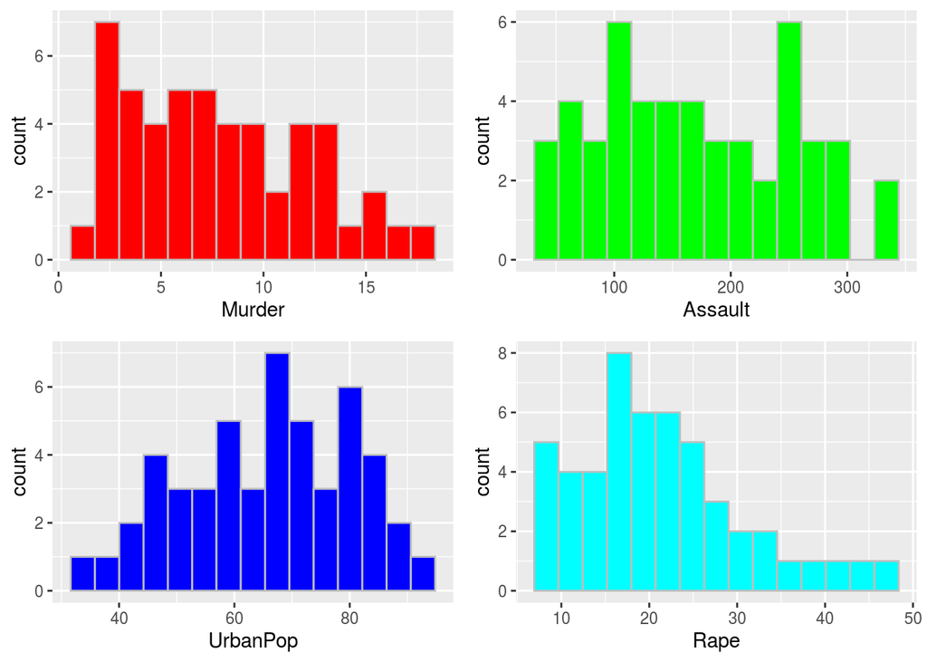

```r
library(ggplot2)
data(USArrests)
dataset <- USArrests
#names(dataset)
#head(dataset)
g1 <- ggplot(mapping = aes(Murder), dataset) +
  geom_histogram(bins=15, fill ="red", color="grey")

g2 <- ggplot(mapping = aes(Assault), dataset) +
  geom_histogram(bins=15, fill ="green", color="grey")

g3 <- ggplot(mapping = aes(UrbanPop), dataset) +
  geom_histogram(bins=15, fill ="blue", color="grey")

g4 <- ggplot(mapping = aes(Rape), dataset) +
  geom_histogram(bins=15, fill ="cyan", color="grey")

library("gridExtra")
grid.arrange(g1, g2, g3, g4, nrow=2, ncol=2)
```

## Questão 2

Escolha duas variáveis do banco de dados para fazer um diagrama de dispersão (scatterplot), usando geom_point. Acrescente uma linha relacionando as duas variáveis para ajudar na interpretação. Descreva o fenômeno que você quer analisar com esse diagrama.

Resp:

O gráfico abaixo sugere que há uma correlação entre as quantidades de homícidio e violência sexual: o aumento de um destes crimes influencia no aumento do outro. Nota-se ainda que há pontos relacionados a alta quantidade de violência sexual que não seguem esse padrão.

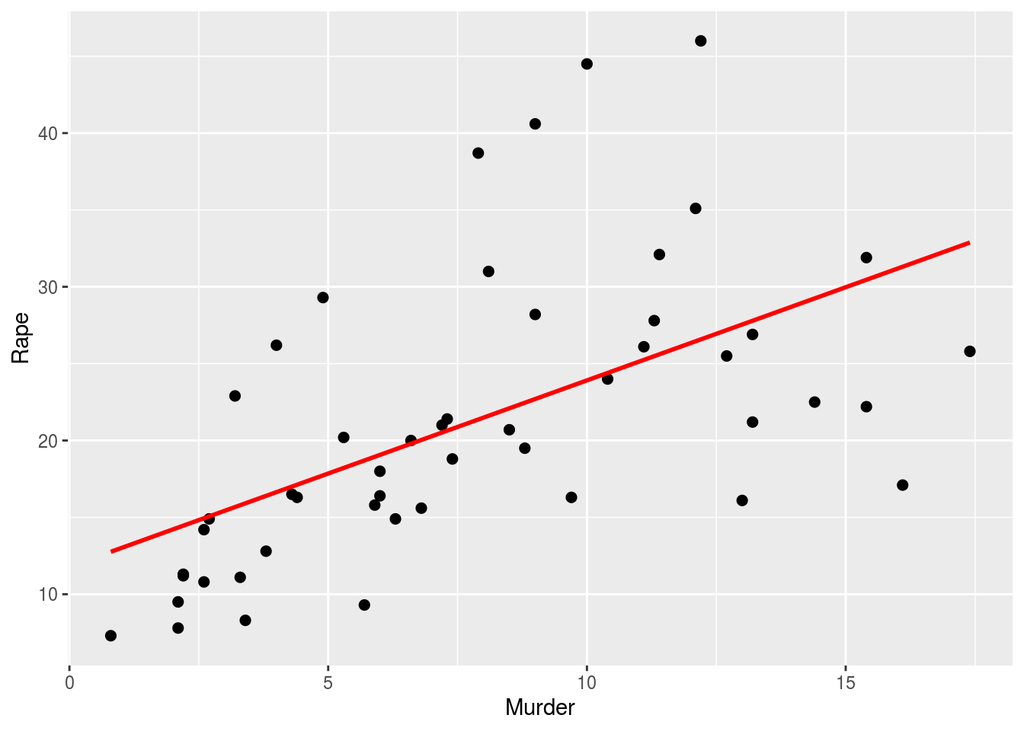

```r
library(ggplot2)
data(USArrests)
dataset <- USArrests
#names(dataset)
g <- ggplot(mapping = aes(x=Murder, y=Rape), dataset) +
  geom_point(size=2) +
  geom_smooth(se=FALSE, method = "lm", color="red")

g
```

## Questão 3

Utilizando a função data() do R, escolha um conjunto de dados de sua preferência e crie 4 gráficos, a sua escolha, usando as variáveis deste banco de dados. Faça uma breve interpretação de seus achados.

Resp:

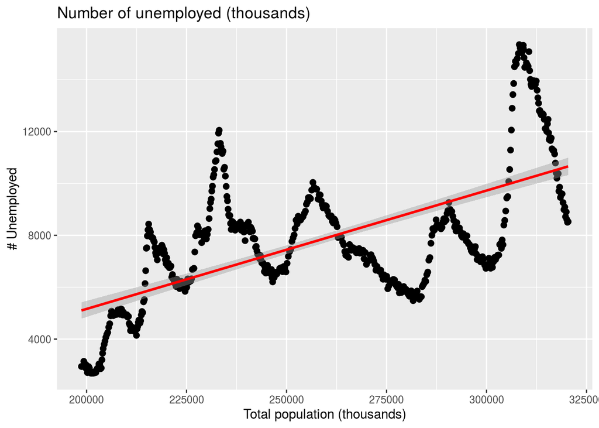

```r
library(ggplot2)
#?ggplot
data(economics) # US economic time series
#help(economics)
dataset <- economics
#head(dataset)
#names(dataset)
#summary(dataset$pop)

g1 <- ggplot(mapping = aes(x=pop, y=unemploy), dataset) +
  geom_point(size=2) +
  geom_smooth(method = "lm", color="red")+
labs(title = 'Number of unemployed (thousands)',
     y = '# Unemployed',
     x = 'Total population (thousands)')
g1
```

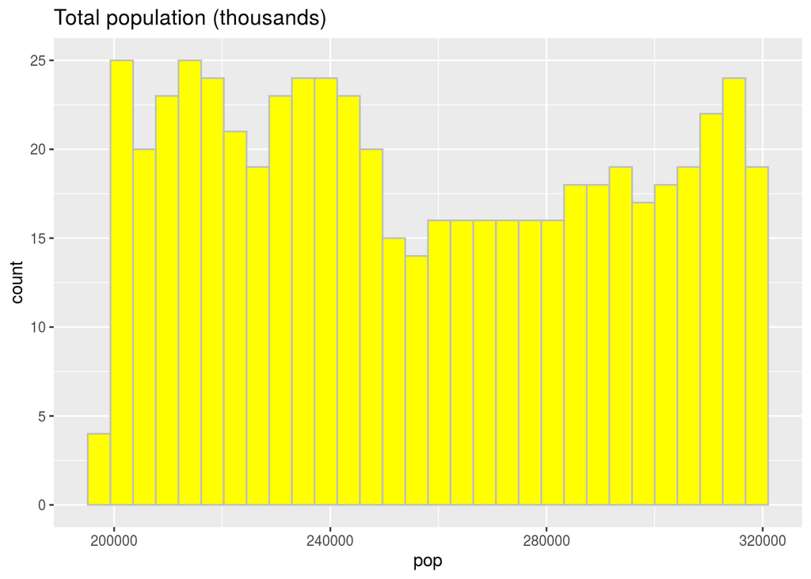

```r
g2 <- ggplot(mapping = aes(pop), dataset) +
  geom_histogram(bins=30, fill ="yellow", color="grey") +
  labs(title = 'Total population (thousands)')
g2
```

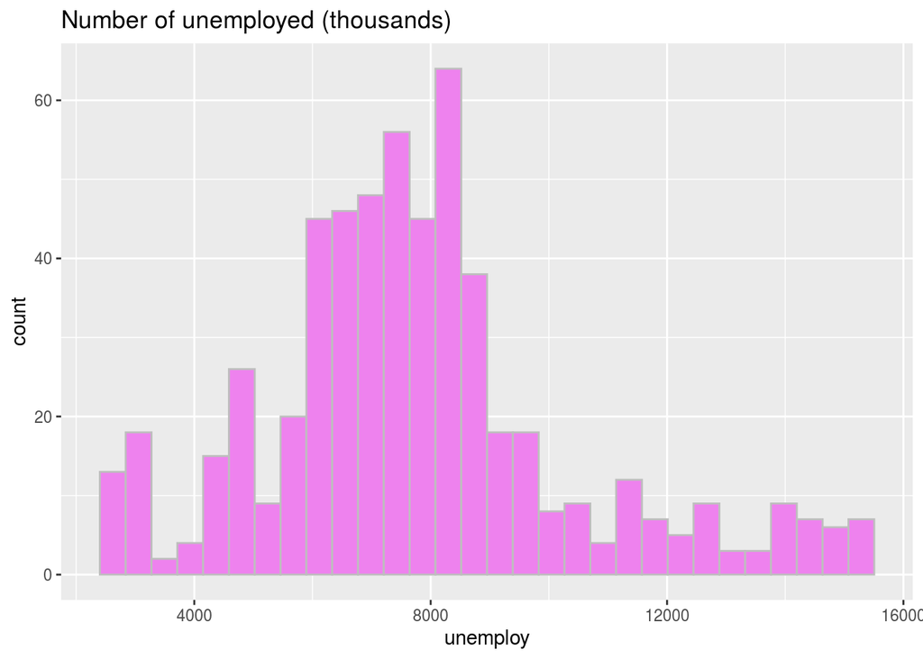

```r
g3 <- ggplot(mapping = aes(unemploy), dataset) +
  geom_histogram(bins=30, fill ="violet", color="grey") +
  labs(title = 'Number of unemployed (thousands)')
g3
```

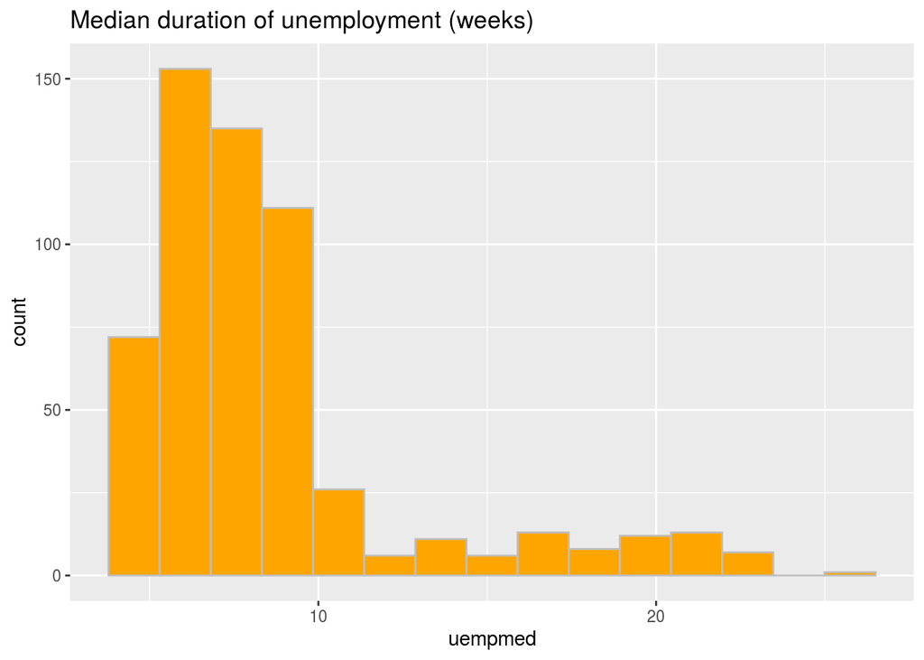

```r
g4 <- ggplot(mapping = aes(uempmed), dataset) +
  geom_histogram(bins=15, fill ="orange", color="grey") +
  labs(title = "Median duration of unemployment (weeks)")
g4
```

As análises aqui se referem a dados sobre os USA.

Nota-se pelos gráficos que a quantidade de desempregados (‘unemployed’) tende a aumentar conforme a população total aumenta. Esse aumento possui um comportamento oscilatório.

## Questão 4

Considerando o banco de dados utilizado no exercício anterior, escolha duas variáveis para analisar via diagrama de dispersão. Comente brevemente seus achados.

Resp:

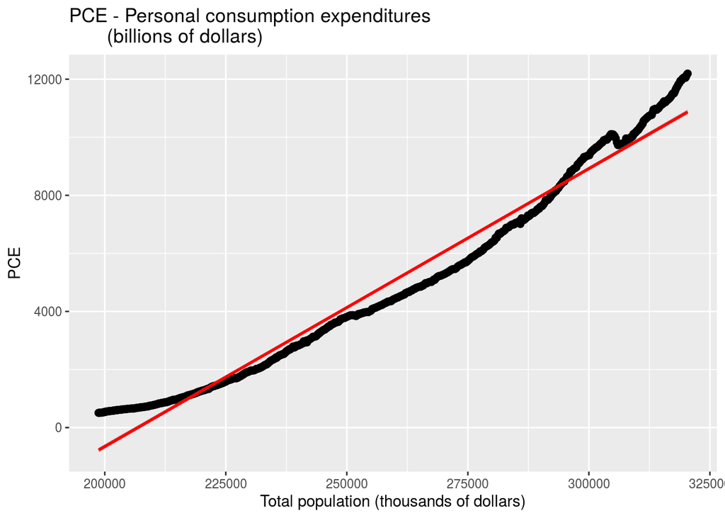

```r
library(ggplot2)
data(economics) # US economic time series
dataset <- economics

g1 <- ggplot(mapping = aes(x=pop, y=pce), dataset) +
  geom_point(size=2) +
  geom_smooth(method = "lm", color="red") +
  labs(title = 'PCE - Personal consumption expenditures
       (billions of dollars)',
       y = 'PCE',
       x = 'Total population (thousands of dollars)')
g1
```

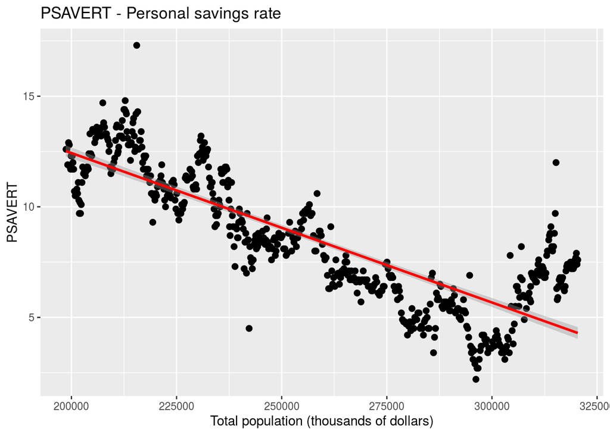

```r
g2 <- ggplot(mapping = aes(x=pop, y=psavert), dataset) +
  geom_point(size=2) +
  geom_smooth(method = "lm", color="red") +
  labs(title = 'PSAVERT - Personal savings rate',
       y = 'PSAVERT',
       x = 'Total population (thousands of dollars)')
g2
```

## Questão 5

Utilize o comando ?mpg e descreva as variáveis contidas neste banco de dados. Faça uma análise preliminar deste banco de dados usando os comando head, tail, etc (como fizemos para USArrests).

Resp:

```r
library(ggplot2)
#?mpg
data(mpg) # Fuel economy data from 1999 and 2008 for 38 popular models of car
dataset <- mpg

head(dataset)
```

```
## # A tibble: 6 x 11
##   manufacturer model displ  year   cyl trans      drv     cty   hwy fl    class
##   <chr>        <chr> <dbl> <int> <int> <chr>      <chr> <int> <int> <chr> <chr>
## 1 audi         a4      1.8  1999     4 auto(l5)   f        18    29 p     compa…
## 2 audi         a4      1.8  1999     4 manual(m5) f        21    29 p     compa…
## 3 audi         a4      2    2008     4 manual(m6) f        20    31 p     compa…
## 4 audi         a4      2    2008     4 auto(av)   f        21    30 p     compa…
## 5 audi         a4      2.8  1999     6 auto(l5)   f        16    26 p     compa…
## 6 audi         a4      2.8  1999     6 manual(m5) f        18    26 p     compa…
```

```r
tail(dataset)
```

```
## # A tibble: 6 x 11
##   manufacturer model  displ  year   cyl trans     drv     cty   hwy fl    class
##   <chr>        <chr>  <dbl> <int> <int> <chr>     <chr> <int> <int> <chr> <chr>
## 1 volkswagen   passat   1.8  1999     4 auto(l5)  f        18    29 p     midsi…
## 2 volkswagen   passat   2    2008     4 auto(s6)  f        19    28 p     midsi…
## 3 volkswagen   passat   2    2008     4 manual(m… f        21    29 p     midsi…
## 4 volkswagen   passat   2.8  1999     6 auto(l5)  f        16    26 p     midsi…
## 5 volkswagen   passat   2.8  1999     6 manual(m… f        18    26 p     midsi…
## 6 volkswagen   passat   3.6  2008     6 auto(s6)  f        17    26 p     midsi…
```

```r
names(dataset)
```

```
##  [1] "manufacturer" "model"        "displ"        "year"         "cyl"
##  [6] "trans"        "drv"          "cty"          "hwy"          "fl"
## [11] "class"
```

```r
summary(dataset)
```

```
##  manufacturer          model               displ            year
##  Length:234         Length:234         Min.   :1.600   Min.   :1999
##  Class :character   Class :character   1st Qu.:2.400   1st Qu.:1999
##  Mode  :character   Mode  :character   Median :3.300   Median :2004
##                                        Mean   :3.472   Mean   :2004
##                                        3rd Qu.:4.600   3rd Qu.:2008
##                                        Max.   :7.000   Max.   :2008
##       cyl           trans               drv                 cty
##  Min.   :4.000   Length:234         Length:234         Min.   : 9.00
##  1st Qu.:4.000   Class :character   Class :character   1st Qu.:14.00
##  Median :6.000   Mode  :character   Mode  :character   Median :17.00
##  Mean   :5.889                                         Mean   :16.86
##  3rd Qu.:8.000                                         3rd Qu.:19.00
##  Max.   :8.000                                         Max.   :35.00
##       hwy             fl               class
##  Min.   :12.00   Length:234         Length:234
##  1st Qu.:18.00   Class :character   Class :character
##  Median :24.00   Mode  :character   Mode  :character
##  Mean   :23.44
##  3rd Qu.:27.00
##  Max.   :44.00
```

Sobre o dataset ‘mpg’:

"Fuel economy data from 1999 and 2008 for 38 popular models of car

Description This dataset contains a subset of the fuel economy data that the EPA makes available on http://fueleconomy.gov. It contains only models which had a new release every year between 1999 and 2008 - this was used as a proxy for the popularity of the car.

Usage mpg Format A data frame with 234 rows and 11 variables

manufacturer model model name

displ engine displacement, in litres

year year of manufacture

cyl number of cylinders

trans type of transmission

drv f = front-wheel drive, r = rear wheel drive, 4 = 4wd

cty city miles per gallon

hwy highway miles per gallon

fl fuel type

class “type” of car"

## Questão 6

Faça um gráfico de dispersão entre as variáveis hwy e cyl. Mude a cor do tema. Interprete os resultados.

Resp:

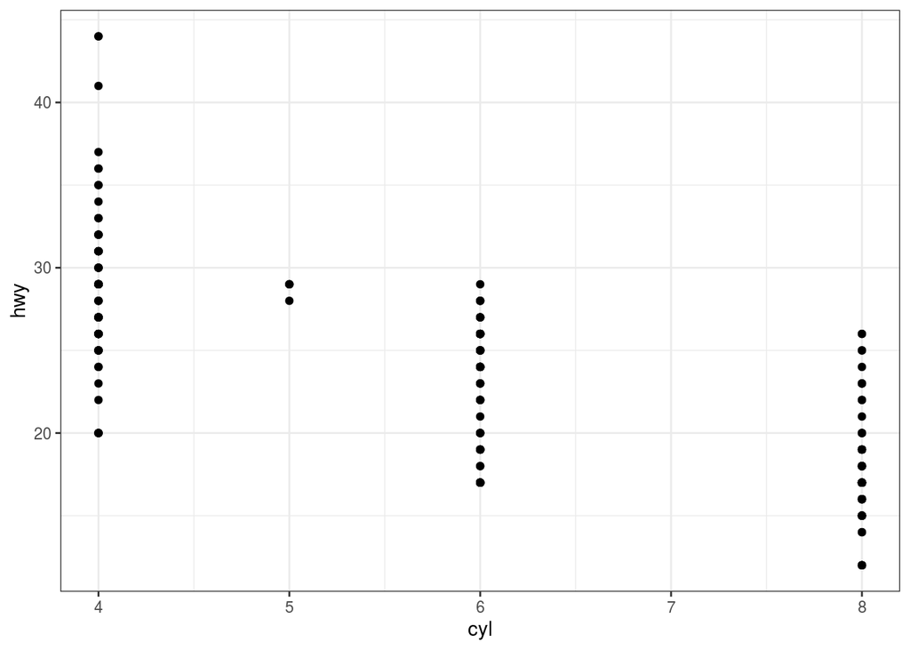

```r
library(ggplot2)
data(mpg)
#summary(mpg$hwy)
#?mpg
dataset <- mpg
ggplot(mapping = aes(x=cyl, y=hwy), data=dataset) +
  geom_point() +
  theme_bw()
```

```r
#?theme_gray
```

## Questão 7

Escolha duas variáveis do banco de dados e construa histograma e box-plot para elas. Personalize os gráficos usando cores diferentes do default. Não se esqueça de dar nomes para os eixos, bem como um título para os gráficos. Organize os gráficos em subplots usando gride.arrange(). Note que teremos 2 histogramas e 2 boxplots, totalizando 4 gráficos que vc deve plotar em duas colunas.

Resp:

[figure not shown]

```r
library(ggplot2)
data(mpg)
dataset <- mpg

g1 <- ggplot(mapping = aes(cyl), dataset) +
  geom_histogram(bins=15, fill ="violet", color="white") +
  labs(title = "Histogram",
       y = '# Cars',
       x = 'Number of cylinders')

g2 <- ggplot(mapping = aes(cty), dataset) +
  geom_histogram(bins=15, fill ="orange", color="gray") +
  labs(title = "Histogram",
       y = '# Cars',
       x = 'City miles per gallon')

g3 <- ggplot(mapping = aes(x=class, y=cty), data=dataset) +
  geom_boxplot(fill="blue", color="blue") +
  labs(title = "Box-plot",
       y = 'Number of cylinders',
       x = '"Type" of car')

g4 <- ggplot(mapping = aes(x=class, y=hwy), data=dataset) +
  geom_boxplot(fill="green", color="gray") +
  labs(title = "Box-plot",
       y = 'Highway miles per gallon',
       x = '"Type" of car')

library("gridExtra")
grid.arrange(g1, g2, g3, g4, nrow=2, ncol=2)
```

## Questão 8

Usando o arquivo de dados mpg ainda, vamos agora treinar o uso do recurso facet.

1. Faça gráficos de dispersão entre displ e hwy separados para cada classe de veículos. Use color = class para diferenciar por cor e facet wrap(~ class, nrow=2) para obter os subplots.

Resp:

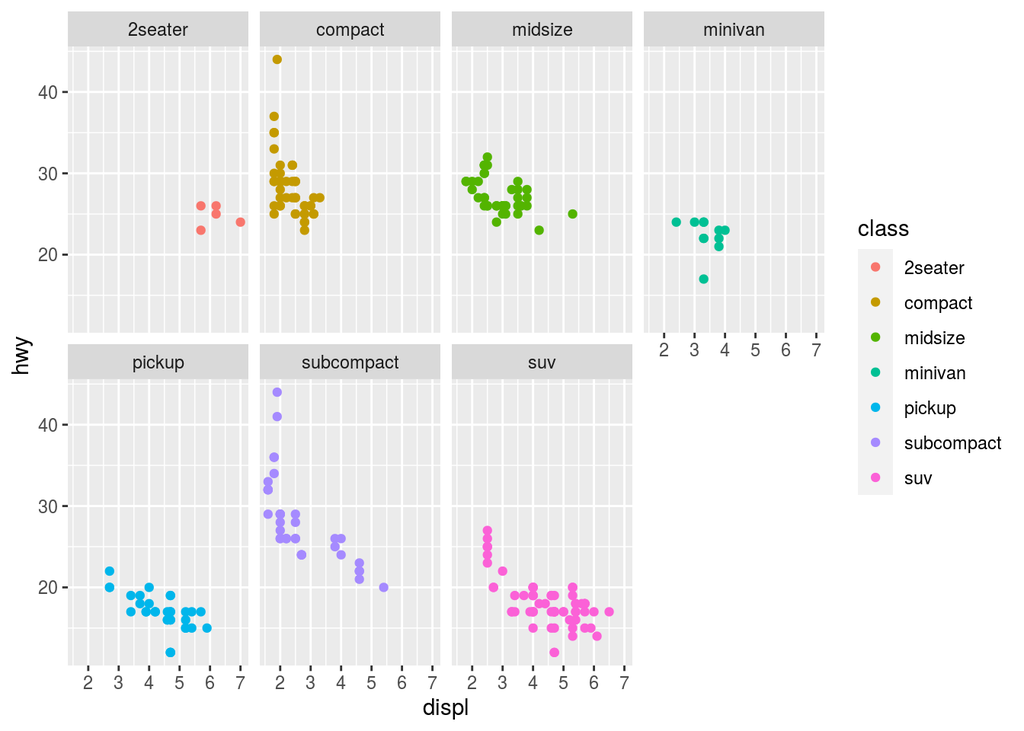

```r
library(ggplot2)
data(mpg)
#?mpg
dataset <- mpg
#head(dataset)
#?facet_wrap
#? facet_grid

g1 <- ggplot(data = dataset) +
  geom_point(mapping = aes(x=displ, y=hwy, color=class)) +
  facet_wrap(~class, nrow=2)
g1
```

2. Agora vamos criar subplots com base em duas variáveis: número de cilindros (cyl) e tipo de direção (drv). Diferencie por cor usando color=drv e utilize facet grid(drv ~ cyl). Algumas facetas ficarão vazias por não possuírem combinações de drv e cyl.

Resp:

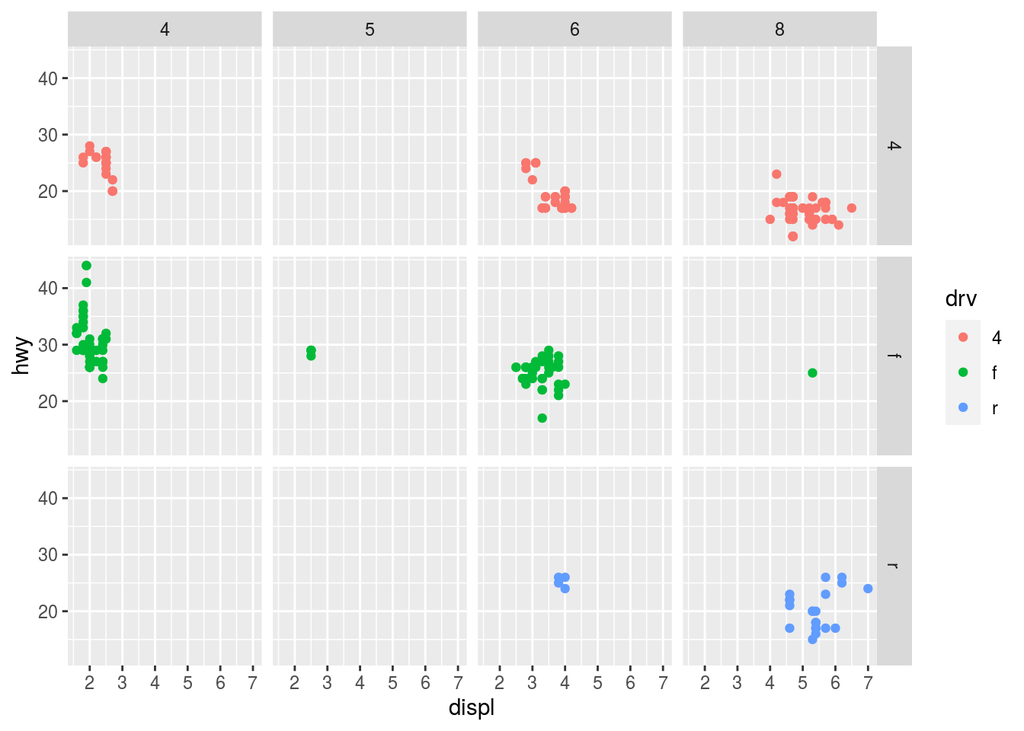

```r
library(ggplot2)
data(mpg)
dataset <- mpg

g2 <- ggplot(data = dataset) +
  geom_point(mapping = aes(x=displ, y=hwy, color=drv)) +
  facet_grid(drv ~ cyl)
g2
```

3. Explique o que ocorre se você usar color=cyl para classifcar por cilindros (cyl) e facet_grid(. ~ cyl).

Resp:

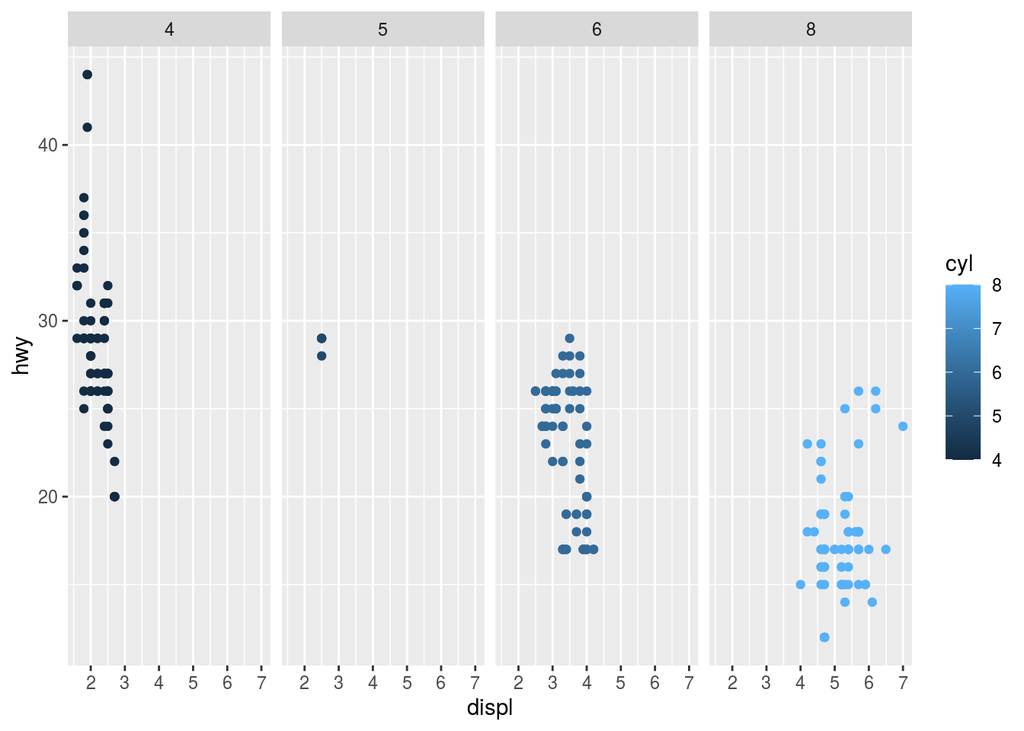

```r
library(ggplot2)
data(mpg)
dataset <- mpg
?facet_grid
#?facet_wrap

g3 <- ggplot(data = dataset) +
  geom_point(mapping = aes(x=displ, y=hwy, color=cyl)) +
  # facet_wrap(~cyl)
  facet_grid(. ~ cyl)
g3
```

Colocando color=cyl as cores agora variam de acordo com o número de cilindro. Já o comando facet_grid(. ~ cyl) divide em colunas baseado em no número de cilindros (‘cyl’).

## Questão 9

*Corrupção x desenvolvimento humano*. Para realizar este exercício, usaremos um banco de dados disponibilizado na página do nosso curso (homework3.xls). Para carregar este conjunto de dados no R, execute os seguintes comandos:

library(readxl)

homework2 = read_excel(”homework2.xlsx”)

OBS: Lembre-se de salvar o arquivo na pasta usada como diretório do R.

Os dados dizem respeito basicamente ao índice de desenvolvimento humano (HDI) e percepção da corrupção (CPI).

1. Construa um diagrama de dispersão entre as variáveis CPI (eixo x) e HDI (eixo y). Coloque a cor vermelha nos pontos.

Resp:

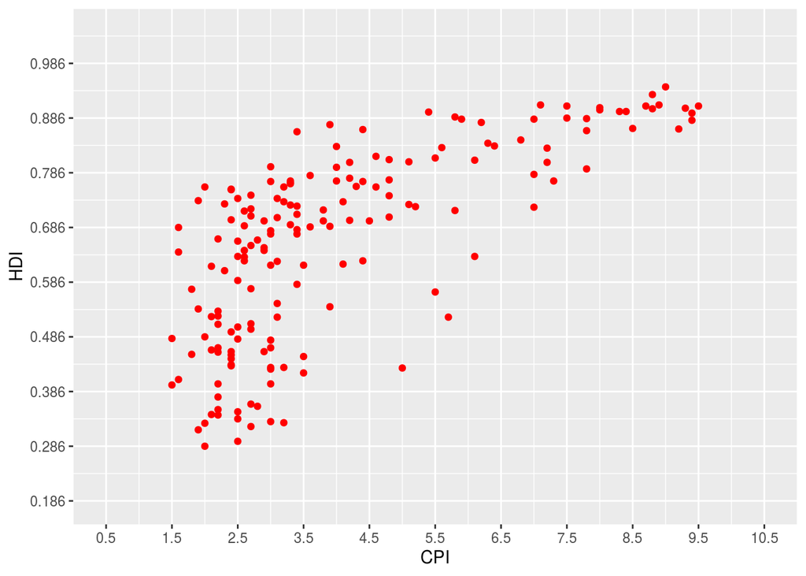

```r
library(ggplot2)
library(readxl)
dataset <- read_excel("homework2.xlsx")
#head(dataset)
#str(dataset)
dataset$CPI <- as.numeric(dataset$CPI)
dataset$HDI <- as.numeric(dataset$HDI)

min_cpi <- min(dataset$CPI)
max_cpi <- max(dataset$CPI)
min_hdi <- min(dataset$HDI)
max_hdi <- max(dataset$HDI)

g1 <- ggplot(data = dataset) +
  geom_point(mapping = aes(x=CPI, y=HDI), color="red") +
  scale_x_continuous(limits = c(min_cpi-1, max_cpi+1),
                     breaks = seq(min_cpi-1, max_cpi+1, 1)) +
  scale_y_continuous(limits = c(min_hdi-0.1, max_hdi+0.1),
                     breaks = seq(min_hdi-0.1, max_hdi+0.1, 0.1))

g1
```

2. Agora diferencie a cor dos pontos por região.

Resp:

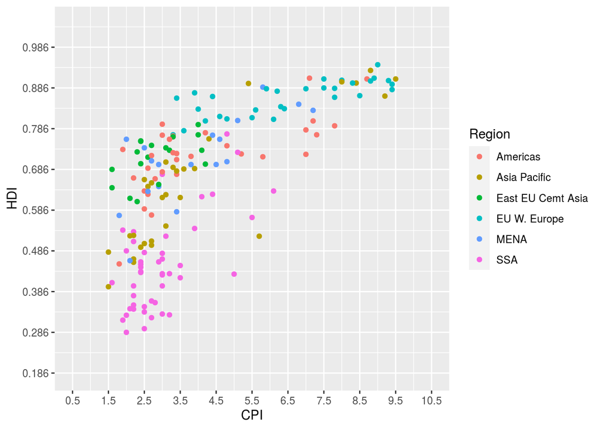

```r
library(ggplot2)
library(readxl)
dataset <- read_excel("homework2.xlsx")
#head(dataset)
#str(dataset)
dataset$CPI <- as.numeric(dataset$CPI)
dataset$HDI <- as.numeric(dataset$HDI)

min_cpi <- min(dataset$CPI)
max_cpi <- max(dataset$CPI)
min_hdi <- min(dataset$HDI)
max_hdi <- max(dataset$HDI)

g1 <- ggplot(data = dataset) +
  geom_point(mapping = aes(x=CPI, y=HDI, color=Region)) +
  scale_x_continuous(limits = c(min_cpi-1, max_cpi+1),
                     breaks = seq(min_cpi-1, max_cpi+1, 1)) +
  scale_y_continuous(limits = c(min_hdi-0.1, max_hdi+0.1),
                     breaks = seq(min_hdi-0.1, max_hdi+0.1, 0.1))

g1
```

3. Faça um gráfico com pontos maiores (size=3).

Resp:

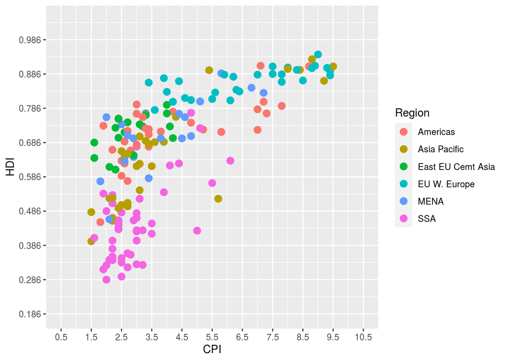

```r
library(ggplot2)
library(readxl)
dataset <- read_excel("homework2.xlsx")
#head(dataset)
#str(dataset)
dataset$CPI <- as.numeric(dataset$CPI)
dataset$HDI <- as.numeric(dataset$HDI)

min_cpi <- min(dataset$CPI)
max_cpi <- max(dataset$CPI)
min_hdi <- min(dataset$HDI)
max_hdi <- max(dataset$HDI)

g1 <- ggplot(data = dataset) +
  geom_point(mapping = aes(x=CPI, y=HDI, color=Region), size=3) +
  scale_x_continuous(limits = c(min_cpi-1, max_cpi+1),
                     breaks = seq(min_cpi-1, max_cpi+1, 1)) +
  scale_y_continuous(limits = c(min_hdi-0.1, max_hdi+0.1),
                     breaks = seq(min_hdi-0.1, max_hdi+0.1, 0.1))

g1
```

4. Faça um gráfico em que o tamanho dos pontos dependa da variável HDI.

Resp:

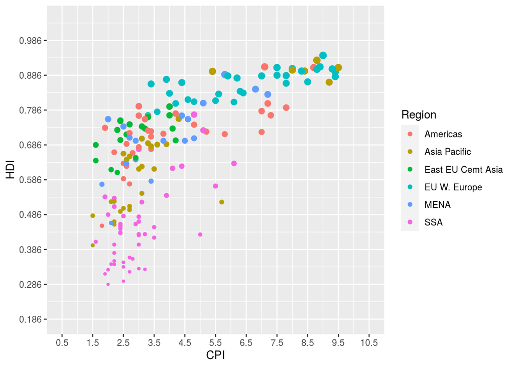

```r
library(ggplot2)
library(readxl)
dataset <- read_excel("homework2.xlsx")
#head(dataset)
#str(dataset)
dataset$CPI <- as.numeric(dataset$CPI)
dataset$HDI <- as.numeric(dataset$HDI)
#summary(dataset$HDI)

min_cpi <- min(dataset$CPI)
max_cpi <- max(dataset$CPI)
min_hdi <- min(dataset$HDI)
max_hdi <- max(dataset$HDI)

g1 <- ggplot(data = dataset) +
  geom_point(mapping = aes(x=CPI, y=HDI, color=Region), size=3*dataset$HDI) +
  scale_x_continuous(limits = c(min_cpi-1, max_cpi+1),
                     breaks = seq(min_cpi-1, max_cpi+1, 1)) +
  scale_y_continuous(limits = c(min_hdi-0.1, max_hdi+0.1),
                     breaks = seq(min_hdi-0.1, max_hdi+0.1, 0.1))

g1
```

5. Inclua nomes nos eixos x e y, um título para o seu gráfico bem como legendas que julgar necessárias.

Resp:

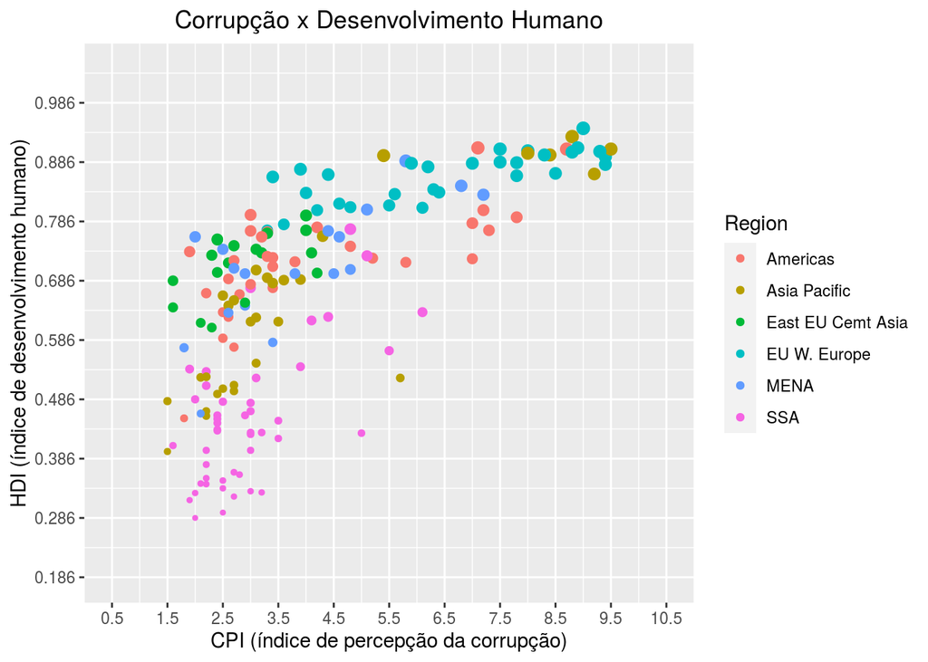

```r
library(ggplot2)
library(readxl)
dataset <- read_excel("homework2.xlsx")
#head(dataset)
#str(dataset)
dataset$CPI <- as.numeric(dataset$CPI)
dataset$HDI <- as.numeric(dataset$HDI)
#summary(dataset$HDI)
#head(dataset)

min_cpi <- min(dataset$CPI)
max_cpi <- max(dataset$CPI)
min_hdi <- min(dataset$HDI)
max_hdi <- max(dataset$HDI)

g1 <- ggplot(data = dataset) +
  geom_point(mapping = aes(x=CPI, y=HDI, color=Region), size=3*dataset$HDI) +
  scale_x_continuous(limits = c(min_cpi-1, max_cpi+1),
                     breaks = seq(min_cpi-1, max_cpi+1, 1)) +
  scale_y_continuous(limits = c(min_hdi-0.1, max_hdi+0.1),
                     breaks = seq(min_hdi-0.1, max_hdi+0.1, 0.1)) +
  labs(title = 'Corrupção x Desenvolvimento Humano',
       y = 'HDI (índice de desenvolvimento humano)',
       x = 'CPI (índice de percepção da corrupção)') +
  theme(plot.title = element_text(hjust = 0.5))


g1
```

6. Desafio: O gráfico abaixo foi publicado na revista The Economist e utiliza os dados contidos no arquivo que estamos usando. Escreva um código no R usando ggplot que replica tão próximo quanto possível o gráfico em questão.

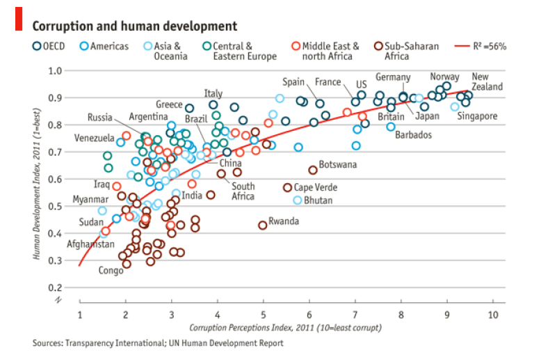

fonte: The Economist

Resp:

```r
library(dplyr)
```

```r
library(ggplot2)
library(readxl)
dataset <- read_excel("homework2.xlsx")
head(dataset)
```

```
## # A tibble: 6 x 5
##   Country     HDI_Rank HDI   CPI   Region
##   <chr>          <dbl> <chr> <chr> <chr>
## 1 Afghanistan      172 0.398 1.5   Asia Pacific
## 2 Albania           70 0.739 3.1   East EU Cemt Asia
## 3 Algeria           96 0.698 2.9   MENA
## 4 Angola           148 0.486 2     SSA
## 5 Argentina         45 0.797 3     Americas
## 6 Armenia           86 0.716 2.6   East EU Cemt Asia
```

```r
tail(dataset)
```

```
## # A tibble: 6 x 5
##   Country    HDI_Rank HDI   CPI   Region
##   <chr>         <dbl> <chr> <chr> <chr>
## 1 Uzbekistan      115 0.641 1.6   East EU Cemt Asia
## 2 Vanuatu         125 0.617 3.5   Asia Pacific
## 3 Venezuela        73 0.735 1.9   Americas
## 4 Yemen           154 0.462 2.1   MENA
## 5 Zambia          164 0.43  3.2   SSA
## 6 Zimbabwe        173 0.376 2.2   SSA
```

```r
str(dataset)
```

```
## tibble [173 × 5] (S3: tbl_df/tbl/data.frame)
##  $ Country : chr [1:173] "Afghanistan" "Albania" "Algeria" "Angola" ...
##  $ HDI_Rank: num [1:173] 172 70 96 148 45 86 2 19 91 53 ...
##  $ HDI     : chr [1:173] "0.398" "0.739" "0.698" "0.486" ...
##  $ CPI     : chr [1:173] "1.5" "3.1" "2.9" "2" ...
##  $ Region  : chr [1:173] "Asia Pacific" "East EU Cemt Asia" "MENA" "SSA" ...
```

```r
dataset$CPI <- as.numeric(dataset$CPI)
dataset$HDI <- as.numeric(dataset$HDI)
require("ggrepel")
#summary(dataset$HDI)
#head(dataset)

#titulo <- expression(paste("No. of ", bold("bacteria X"), " isolates with corresponding types"))

summary(dataset$CPI)
```

```
##    Min. 1st Qu.  Median    Mean 3rd Qu.    Max.
##   1.500   2.500   3.200   4.052   5.100   9.500
```

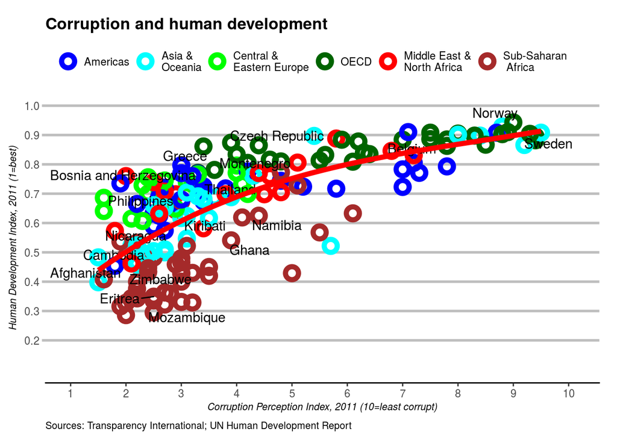

```r
#?geom_point
g <- ggplot(mapping = aes(x=CPI, y=HDI), data = dataset) +
  geom_point(aes(colour=factor(Region)),
             shape=21, stroke=3, size=3, fill = NA) +
  #geom_text_repel(data=subset(dataset, dataset$CPI < quantile(dataset$CPI, 0.5)),
  #                            label=factor(dataset$Country),
  #                            hjust=1, vjust=1) +
  geom_text_repel(data=dataset %>%
                    filter(dataset$CPI > 1  | dataset$CPI < 10) %>%
                             sample_n(18),
                  aes(label=Country))+
                  #label=factor(dataset$Country),
                  #hjust=1, vjust=1) +
  scale_x_continuous(limits = c(1, 10.1),
                     breaks = seq(1, 10.1, 1)) +
  scale_y_continuous(limits = c(0.1, 1),
                     breaks = seq(0.2, 1, 0.1)) +
  geom_smooth(method = lm,
              formula = y ~ splines::bs(x, 3),
              se = FALSE, color="red", size = 2) +
  labs(title = expression(paste(bold('Corruption and human development'))),
       y = expression(paste(italic('Human Development Index, 2011 (1=best)'))),
       x = expression(paste(italic('Corruption Perception Index, 2011 (10=least corrupt)'))),
       caption = "Sources: Transparency International; UN Human Development Report",
       color = ""
       ) +
  scale_color_manual(name="",
                       labels= c("Americas","Asia &\nOceania","Central &\nEastern Europe",
                                 "OECD", "Middle East &\nNorth Africa","Sub-Saharan\n Africa"),
                       values=c("blue","cyan","green",
                                "darkgreen","red","brown")) +
  theme_classic() +
  guides( col = guide_legend(nrow = 1))+
  theme(axis.title=element_text(size=8, face="italic"),
        plot.caption = element_text(hjust = 0.0, size=8),
        #axis.line=element_blank(),
        axis.line.y = element_blank(),
        axis.line.x = element_line(lineend="round"),
        #axis.text.x=element_blank(), axis.text.y=element_blank(),
        #axis.ticks=element_blank(),
        axis.ticks.length=unit(0.2, "lines"),
        axis.ticks.y = element_line(colour= "gray", size=1),
        #axis.title.x=element_blank(),
        #axis.title.y=element_blank(),
        legend.background=element_rect(fill="white", colour=NA),
        #legend.key=element_rect(colour="white"),
        #legend.key.size=unit(1.2, "lines"),
        legend.position='top',
        #legend.text=element_text(size=rel(0.8)),
        legend.justification='left',
        legend.direction='horizontal',
        legend.title=element_text(size=rel(0.8), face="bold", hjust=0), panel.background=element_blank(),
        panel.border=element_blank(),
        #panel.grid.major.x=element_blank(),
        #panel.grid.minor.x=element_blank(),
        panel.grid.minor = element_blank(),
        panel.grid.major.y = element_line(colour= "gray",size=1),
        #plot.background=element_blank(),
        plot.margin=unit(c(1, 1, 0.5, 0.5), "lines"), plot.title=element_text(size=rel(1.2)),
        strip.background=element_rect(fill="grey90", colour="grey50"),
        strip.text.y=element_text(size=rel(0.8), angle=-90))

g
```